# Self Regulation Ontology DDM Analyses

## Loading datasets

The tasks included in this report are:

```r
measure_labels <- read.csv('/Users/zeynepenkavi/Dropbox/PoldrackLab/SRO_Retest_Analyses/input/measure_labels.csv')

measure_labels = measure_labels %>% select(-measure_description)

measure_labels = measure_labels %>%
  filter(ddm_task == 1)

measure_labels = measure_labels %>%
  mutate(dv = as.character(dv)) %>%
  separate(dv, c("task_group", "var"), sep = "\\.", remove=FALSE, extra = "merge")

unique(measure_labels$task_group)
```

```
 [1] "adaptive_n_back"             "attention_network_task"
 [3] "choice_reaction_time"        "directed_forgetting"
 [5] "dot_pattern_expectancy"      "local_global_letter"
 [7] "motor_selective_stop_signal" "recent_probes"
 [9] "shape_matching"              "simon"
[11] "stim_selective_stop_signal"  "stop_signal"
[13] "stroop"                      "threebytwo"
```

```
adaptive_n_back

attention_network_task

choice_reaction_time

directed_forgetting

dot_pattern_expectancy

local_global_letter

motor_selective_stop_signal

recent_probes

shape_matching

simon

stim_selective_stop_signal

stop_signal

stroop

threebytwo
```

### Load time 1 data

```r
test_data <- read.csv(paste0(retest_data_path,'t1_data/variables_exhaustive.csv'))

test_data_subs = as.character(test_data$X)

test_data = test_data %>%
  select(measure_labels$dv)

test_data$sub_id = test_data_subs

rm(test_data_subs)
```

### Load time 2 data

```r
retest_data <- read.csv(paste0(retest_data_path,'variables_exhaustive.csv'))

retest_data_subs = as.character(retest_data$X)

retest_data = retest_data %>%
  select(measure_labels$dv)

retest_data$sub_id = retest_data_subs

retest_data = retest_data[retest_data$sub_id %in% test_data$sub_id,]

rm(retest_data_subs)
```

### HDDM parameters in t1 data

Since HDDM parameters depend on the sample on which they are fit we also refit the model on t1 data only for the subjects that have t2 data.

```r
hddm_refits <- read.csv(paste0(retest_data_path,'t1_data/hddm_refits_exhaustive.csv'))

test_data_hddm_fullfit <- test_data

tmp = names(test_data_hddm_fullfit)[names(test_data_hddm_fullfit) %in% names(hddm_refits) == FALSE]

hddm_refit_subs = as.character(hddm_refits$X)

hddm_refits = hddm_refits[, c(names(hddm_refits) %in% measure_labels$dv)]

hddm_refits$sub_id <- hddm_refit_subs

rm(hddm_refit_subs)

###RERAN MOTOR SS FOR REFIT (MISSING REACTIVE CONTROL HDDM DRIFT) - still missing; while missing the values from fitting to the full sample are used
# after correction this should just be sub_id
#tmp

test_data_hddm_refit = test_data_hddm_fullfit %>%
  select(tmp)

#merge hddm refits to test data
test_data_hddm_refit = merge(test_data_hddm_refit, hddm_refits, by="sub_id")

rm(test_data, hddm_refits, tmp)
```

### Create reliability point estimates

#### Using hddm full sample

```r
#for matching function to work properly assign name back to test_data
test_data  = test_data_hddm_fullfit

numeric_cols = get_numeric_cols()

#Create df of point estimate reliabilities
rel_df_cols = c('icc', 'pearson', 'var_subs', 'var_ind', 'var_resid')

rel_df = as.data.frame(matrix(ncol = length(rel_df_cols)))

names(rel_df) = rel_df_cols

for(i in 1:length(numeric_cols)){

  tmp = get_retest_stats(numeric_cols[i], metric = c('icc', 'pearson', 'var_breakdown'))

  if(i == 1){
    rel_df = tmp
  }
  else{
    rel_df = rbind(rel_df, tmp)
  }
}

row.names(rel_df) <- numeric_cols
rel_df$dv = row.names(rel_df)
row.names(rel_df) = seq(1:nrow(rel_df))
rel_df$task = 'task'
rel_df[grep('survey', rel_df$dv), 'task'] = 'survey'
rel_df[grep('holt', rel_df$dv), 'task'] = "task"
rel_df = rel_df %>%
  select(dv, task, icc, pearson, var_subs, var_ind, var_resid)
```

Reassign df’s and clean up

```r
rel_df_fullfit = rel_df
rm(test_data, rel_df, tmp, i, numeric_cols, rel_df_cols)
```

#### Using hddm retest only sample

```r
#for matching function to work properly assign name back to test_data
test_data  = test_data_hddm_refit

numeric_cols = get_numeric_cols()

#Create df of point estimate reliabilities
rel_df_cols = c('icc', 'pearson', 'var_subs', 'var_ind', 'var_resid')

rel_df = as.data.frame(matrix(ncol = length(rel_df_cols)))

names(rel_df) = rel_df_cols

for(i in 1:length(numeric_cols)){

  tmp = get_retest_stats(numeric_cols[i], metric = c('icc', 'pearson', 'var_breakdown'))

  if(i == 1){
    rel_df = tmp
  }
  else{
    rel_df = rbind(rel_df, tmp)
  }
}

row.names(rel_df) <- numeric_cols
rel_df$dv = row.names(rel_df)
row.names(rel_df) = seq(1:nrow(rel_df))
rel_df$task = 'task'
rel_df[grep('survey', rel_df$dv), 'task'] = 'survey'
rel_df[grep('holt', rel_df$dv), 'task'] = "task"
rel_df = rel_df %>%
  select(dv, task, icc, pearson, var_subs, var_ind, var_resid)
```

Reassign df’s and clean up

```r
rel_df_refit = rel_df
rm(test_data, rel_df, tmp, i, numeric_cols, rel_df_cols)
```

### Load bootstrapped reliabilities

Extract ddm vars only

Using full sample fits’ reliabilities

```r
fullfit_boot_df <- read.csv(gzfile(paste0(retest_data_path,'bootstrap_merged.csv.gz')))
fullfit_boot_df = process_boot_df(fullfit_boot_df)

fullfit_boot_df = fullfit_boot_df[fullfit_boot_df$dv %in% measure_labels$dv,]
```

Refits bootstrapped reliabilities

```r
refit_boot_df = read.csv(gzfile(paste0(retest_data_path,'refits_bootstrap_merged.csv.gz')))
refit_boot_df = process_boot_df(refit_boot_df)
```

## T1 HDDM parameters

Before going on with the rest of the report first decide on whether there are significant differences in the distributions of the HDDM parameter estimates and their reliabilities depending on whether they are fit on the full sample (n=552) or retest sample (n=150) for t1 data.

### Parameter stability

Differences in distributions: using scaled differences

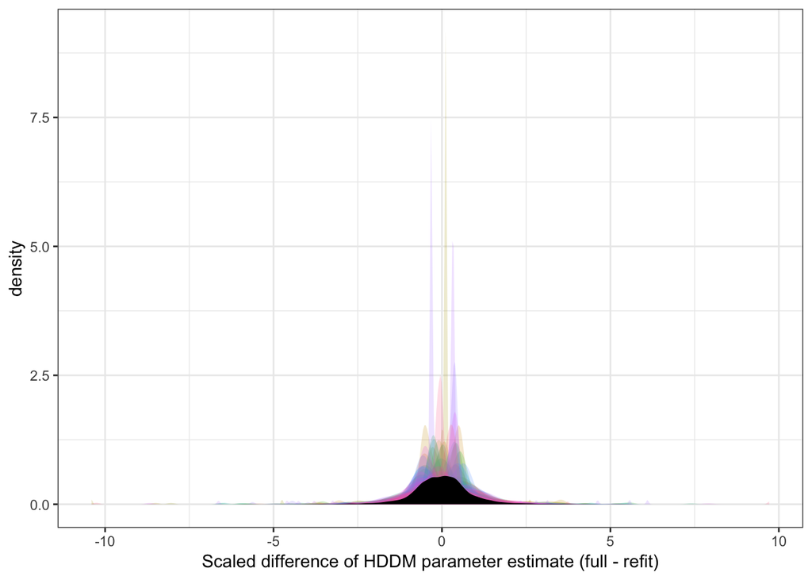

```r
hddm_pars_fullfit = test_data_hddm_fullfit %>%
  select(sub_id, unique(refit_boot_df$dv)) %>%
  mutate(hddm_sample = "fullfit")

hddm_pars_refit = test_data_hddm_refit %>%
  select(sub_id, unique(refit_boot_df$dv)) %>%
  mutate(hddm_sample = "refit")

hddm_pars = rbind(hddm_pars_fullfit, hddm_pars_refit)
rm(hddm_pars_fullfit, hddm_pars_refit)

hddm_pars = hddm_pars %>%
  gather(dv, value, -sub_id, -hddm_sample) %>%
  spread(hddm_sample, value) %>%
  mutate(diff = fullfit - refit) %>%
  group_by(dv) %>%
  mutate(scaled_diff = scale(diff)) %>%
  select(sub_id, dv, scaled_diff) %>%
  left_join(measure_labels[,c("dv", "rt_acc")], by = "dv") %>%
  na.omit()

hddm_pars %>%
  ggplot(aes(scaled_diff))+
  geom_density(aes(fill = dv), alpha = 0.2, color = NA)+
  geom_density(fill = "black", alpha = 1, color=NA)+
  theme(legend.position = "none")+
  xlab("Scaled difference of HDDM parameter estimate (full - refit)")
```

Does the distribution of scaled difference scores (between using n=150 or n=552) have a mean different than 0 allowing for random effects of parameter accounting for the different types of parameters? No.

```r
summary(lmer(scaled_diff ~ rt_acc + (1|dv), hddm_pars))
```

```
Linear mixed model fit by REML ['lmerMod']
Formula: scaled_diff ~ rt_acc + (1 | dv)
   Data: hddm_pars

REML criterion at convergence: 25057

Scaled residuals:
    Min      1Q  Median      3Q     Max
-10.438  -0.501  -0.007   0.460   9.750

Random effects:
 Groups   Name        Variance Std.Dev.
 dv       (Intercept) 1.42e-33 3.77e-17
 Residual             9.93e-01 9.97e-01
Number of obs: 8845, groups:  dv, 62

Fixed effects:
                    Estimate Std. Error t value
(Intercept)         1.90e-17   1.45e-02       0
rt_accnon-decision -3.92e-17   2.66e-02       0
rt_accthreshold     1.73e-20   2.60e-02       0

Correlation of Fixed Effects:
            (Intr) rt_cc-
rt_ccnn-dcs -0.545
rt_ccthrshl -0.558  0.304
```

```r
# Same result
# summary(MCMCglmm(scaled_diff ~ rt_acc, random = ~ dv, data=hddm_pars))
```

### Parameter reliability

Are there differences in reliability depending which sample the HDDM parameters are estimated from? No.

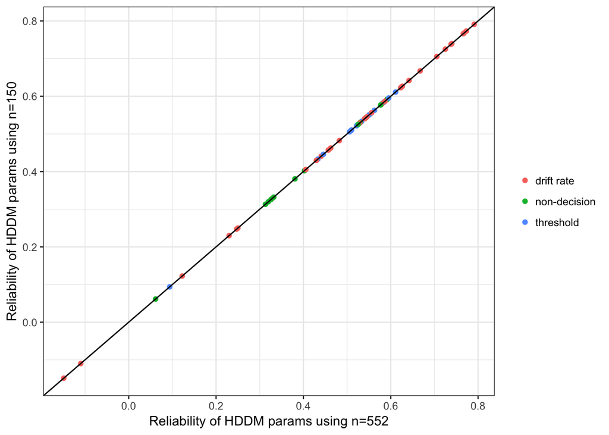

```r
hddm_rels_fullfit = rel_df_fullfit %>%
  filter(dv %in% unique(refit_boot_df$dv)) %>%
  select(dv, icc)

hddm_rels_refit = rel_df_refit %>%
  filter(dv %in% unique(refit_boot_df$dv)) %>%
  select(dv, icc)

hddm_rels = hddm_rels_fullfit %>%
  left_join(hddm_rels_refit, by = "dv") %>%
  rename(fullfit = icc.x, refit = icc.y) %>%
  left_join(measure_labels[,c("dv", "rt_acc")], by = "dv")

rm(hddm_rels_fullfit, hddm_rels_refit)

hddm_rels %>%
  ggplot(aes(fullfit, refit, col=rt_acc))+
  geom_point()+
  geom_abline(slope=1, intercept = 0)+
  xlab("Reliability of HDDM params using n=552")+
  ylab("Reliability of HDDM params using n=150")+
  theme(legend.title = element_blank())
```

```r
hddm_rels = hddm_rels %>%
  gather(sample, value, -dv, -rt_acc)

summary(lmer(value ~ sample*rt_acc + (1|dv), hddm_rels))
```

```
Linear mixed model fit by REML ['lmerMod']
Formula: value ~ sample * rt_acc + (1 | dv)
   Data: hddm_rels

REML criterion at convergence: -1890

Scaled residuals:
      Min        1Q    Median        3Q       Max
-4.55e-07 -3.43e-08  4.37e-08  9.14e-08  2.42e-07

Random effects:
 Groups   Name        Variance Std.Dev.
 dv       (Intercept) 1.98e-02 1.41e-01
 Residual             7.80e-16 2.79e-08
Number of obs: 124, groups:  dv, 62

Fixed effects:
                                Estimate Std. Error t value
(Intercept)                     4.74e-01   2.32e-02   20.41
samplerefit                    -8.61e-16   6.88e-09    0.00
rt_accnon-decision             -5.48e-02   4.42e-02   -1.24
rt_accthreshold                 1.98e-02   4.32e-02    0.46
samplerefit:rt_accnon-decision  9.88e-16   1.26e-08    0.00
samplerefit:rt_accthreshold     1.22e-15   1.23e-08    0.00

Correlation of Fixed Effects:
            (Intr) smplrf rt_cc- rt_cct smp:_-
samplerefit  0.000
rt_ccnn-dcs -0.525  0.000
rt_ccthrshl -0.538  0.000  0.283
smplrft:r_-  0.000 -0.546  0.000  0.000
smplrft:rt_  0.000 -0.559  0.000  0.000  0.305
convergence code: 0
Model failed to converge with max|grad| = 0.127809 (tol = 0.002, component 1)
Model is nearly unidentifiable: very large eigenvalue
 - Rescale variables?
```

You should compare model fits using either sample. That would tell you which estimates explain observed data better though given the lack of difference in parameter estimates I don’t expect these to differ either.

Conclusion: Going to use parameter estimates from refits to retest sample only for t1 data in the rest of this report because I think they are more comparable to the parameter estimates from t2.

Clean up

```r
rm(hddm_pars, hddm_rels)

boot_df = fullfit_boot_df %>%
  filter(dv %in% unique(refit_boot_df$dv) == FALSE)

boot_df = rbind(boot_df, refit_boot_df)

rm(fullfit_boot_df, refit_boot_df)

rel_df = rel_df_refit

rm(rel_df_fullfit, rel_df_refit)

test_data = test_data_hddm_refit

rm(test_data_hddm_fullfit, test_data_hddm_refit)
```

## DDM vs raw reliability overall

Data wrangling df’s containing point estimate reliabilities and bootstrapped reliabilities

```r
rel_df = rel_df %>%
  select(dv, icc, var_subs, var_ind, var_resid) %>%
  left_join(measure_labels[,c("dv", "task_group","overall_difference","raw_fit","rt_acc")], by = "dv") %>%
  mutate(ddm_raw = ifelse(raw_fit == "raw", "raw", "ddm"),
         contrast = ifelse(overall_difference == "difference", "contrast", "non-contrast"))

boot_df = boot_df %>%
  select(dv, icc, var_subs, var_ind, var_resid) %>%
  left_join(measure_labels[,c("dv", "task_group","overall_difference","raw_fit","rt_acc")], by = "dv") %>%
  mutate(ddm_raw = ifelse(raw_fit == "raw", "raw", "ddm"),
         contrast = ifelse(overall_difference == "difference", "contrast", "non-contrast"))
```

Plot reliability point estimates comparing DDM measures to raw measures faceting for contrast measures.

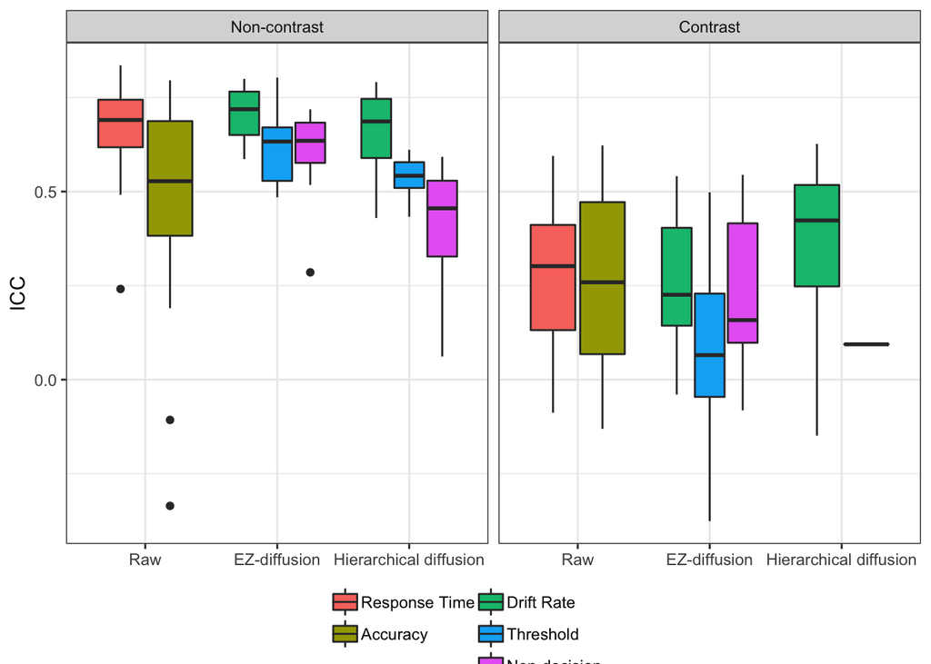

```r
ddm_point_plot = rel_df %>%
  mutate(rt_acc = as.character(rt_acc)) %>%
  filter(rt_acc != "other") %>%
  ggplot(aes(factor(raw_fit, levels = c("raw", "EZ", "hddm"), labels=c("Raw", "EZ-diffusion", "Hierarchical diffusion")), icc, fill=factor(rt_acc, levels = c("rt","accuracy", "drift rate", "threshold", "non-decision"), labels=c("Response Time", "Accuracy","Drift Rate", "Threshold", "Non-decision"))))+
  geom_boxplot()+
  facet_wrap(~factor(contrast, levels=c("non-contrast", "contrast"), labels=c("Non-contrast", "Contrast")))+
  ylab("ICC")+
  xlab("")+
  theme(legend.title = element_blank(),
        legend.position = 'bottom')+
  guides(fill = guide_legend(ncol = 2, byrow=F))

mylegend<-g_legend(ddm_point_plot)

grob_name <- names(mylegend$grobs)[1]

#manually fix the legend
#move non-decision down
#key
mylegend$grobs[grob_name][[1]]$layout[11,c(1:4)] <- c(4,8,4,8)
mylegend$grobs[grob_name][[1]]$layout[12,c(1:4)] <- c(4,8,4,8)
#text
mylegend$grobs[grob_name][[1]]$layout[17,c(1:4)] <- c(4,10,4,10)
#move threshold down
#key
mylegend$grobs[grob_name][[1]]$layout[9,c(1:4)] <- c(3,8,3,8)
mylegend$grobs[grob_name][[1]]$layout[10,c(1:4)] <- c(3,8,3,8)
#text
mylegend$grobs[grob_name][[1]]$layout[16,c(1:4)] <- c(3,10,3,10)
#move drift rate right and up
#key
mylegend$grobs[grob_name][[1]]$layout[7,c(1:4)] <- c(2,8,2,8)
mylegend$grobs[grob_name][[1]]$layout[8,c(1:4)] <- c(2,8,2,8)
#text
mylegend$grobs[grob_name][[1]]$layout[15,c(1:4)] <- c(2,10,2,10)

grid.arrange(ddm_point_plot +theme(legend.position="none"),
             mylegend, nrow=2, heights=c(10, 1))
```

```r
rm(mylegend, ddm_point_plot)
```

Plot averaged bootstrapped reliability estimates per measure comparing DDM measures to raw measures faceting for contrast measures.

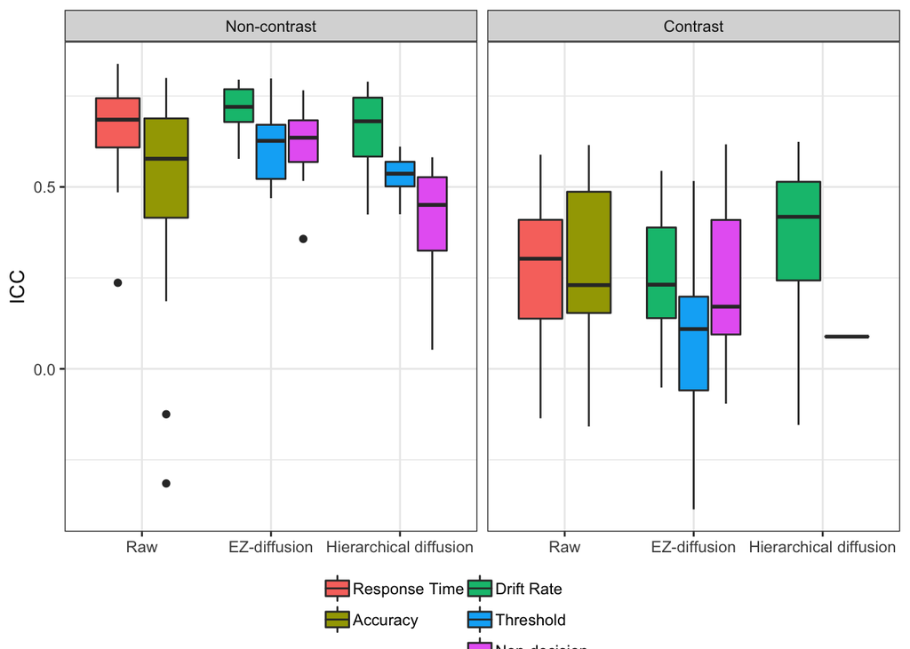

```r
ddm_boot_plot = boot_df %>%
  group_by(dv) %>%
  summarise(mean_icc = mean(icc),
            rt_acc = unique(rt_acc),
            overall_difference = unique(overall_difference),
            raw_fit = unique(raw_fit),
            contrast = unique(contrast)) %>%
  mutate(rt_acc = as.character(rt_acc)) %>%
  filter(rt_acc != "other") %>%
  ggplot(aes(factor(raw_fit, levels = c("raw", "EZ", "hddm"), labels=c("Raw", "EZ-diffusion", "Hierarchical diffusion")), mean_icc, fill=factor(rt_acc, levels = c("rt","accuracy", "drift rate", "threshold", "non-decision"), labels=c("Response Time", "Accuracy","Drift Rate", "Threshold", "Non-decision"))))+
  geom_boxplot()+
  facet_wrap(~factor(contrast, levels=c("non-contrast", "contrast"), labels=c("Non-contrast", "Contrast")))+
  ylab("ICC")+
  xlab("")+
  theme(legend.title = element_blank(),
        legend.position = 'bottom')+
  guides(fill = guide_legend(ncol = 2, byrow=F))

mylegend<-g_legend(ddm_boot_plot)

grob_name <- names(mylegend$grobs)[1]

#manually fix the legend
#move non-decision down
#key
mylegend$grobs[grob_name][[1]]$layout[11,c(1:4)] <- c(4,8,4,8)
mylegend$grobs[grob_name][[1]]$layout[12,c(1:4)] <- c(4,8,4,8)
#text
mylegend$grobs[grob_name][[1]]$layout[17,c(1:4)] <- c(4,10,4,10)
#move threshold down
#key
mylegend$grobs[grob_name][[1]]$layout[9,c(1:4)] <- c(3,8,3,8)
mylegend$grobs[grob_name][[1]]$layout[10,c(1:4)] <- c(3,8,3,8)
#text
mylegend$grobs[grob_name][[1]]$layout[16,c(1:4)] <- c(3,10,3,10)
#move drift rate right and up
#key
mylegend$grobs[grob_name][[1]]$layout[7,c(1:4)] <- c(2,8,2,8)
mylegend$grobs[grob_name][[1]]$layout[8,c(1:4)] <- c(2,8,2,8)
#text
mylegend$grobs[grob_name][[1]]$layout[15,c(1:4)] <- c(2,10,2,10)

grid.arrange(ddm_boot_plot +theme(legend.position="none"),
             mylegend, nrow=2, heights=c(10, 1))
```

```r
rm(mylegend, ddm_boot_plot)
```

Model testing if the reliability of raw measures differs from that of ddm estimates and if contrast measures differ from non-contrast measures.

Checking if both fixed effects of raw vs ddm and contrast vs non-contrast as well as their interaction is necessary.

Conclusion: Model with fixed effect just for contrast and not for raw vs ddm and no interaction is the best. But to answer the question on lack of difference for ddm vs raw I’ll look at the model with both fixed effects for now.

```r
mer1 = lmer(icc ~ ddm_raw + (1|dv), boot_df %>% filter(rt_acc != "other"))
mer1a = lmer(icc ~ contrast + (1|dv), boot_df %>% filter(rt_acc != "other"))
mer2 = lmer(icc ~ ddm_raw + contrast + (1|dv), boot_df %>% filter(rt_acc != "other"))
mer3 = lmer(icc ~ ddm_raw * contrast + (1|dv), boot_df %>% filter(rt_acc != "other"))
anova(mer1, mer2, mer3)
```

```
refitting model(s) with ML (instead of REML)
```

|  | Df | AIC | BIC | logLik | deviance | Chisq | Chi Df | Pr(>Chisq) |
| --- | --- | --- | --- | --- | --- | --- | --- | --- |
| mer1 | 4 | -497367 | -497325 | 248688 | -497375 | NA | NA | NA |
| mer2 | 5 | -497531 | -497478 | 248770 | -497541 | 165.7881 | 1 | 6.154e-38 |
| mer3 | 6 | -497529 | -497466 | 248771 | -497541 | 0.4933 | 1 | 4.824e-01 |

```r
anova(mer1a, mer2, mer3)
```

```
refitting model(s) with ML (instead of REML)
```

|  | Df | AIC | BIC | logLik | deviance | Chisq | Chi Df | Pr(>Chisq) |
| --- | --- | --- | --- | --- | --- | --- | --- | --- |
| mer1a | 4 | -497532 | -497490 | 248770 | -497540 | NA | NA | NA |
| mer2 | 5 | -497531 | -497478 | 248770 | -497541 | 1.2751 | 1 | 0.2588 |
| mer3 | 6 | -497529 | -497466 | 248771 | -497541 | 0.4933 | 1 | 0.4824 |

```r
rm(mer1, mer3, mer1a)
```

Raw measures do not significantly differ from ddm parameters in their reliability but non-contrast measures are significantly more reliable compared to contrast measures.

```r
summary(mer2)
```

```
Linear mixed model fit by REML ['lmerMod']
Formula: icc ~ ddm_raw + contrast + (1 | dv)
   Data: boot_df %>% filter(rt_acc != "other")

REML criterion at convergence: -497522

Scaled residuals:
    Min      1Q  Median      3Q     Max
-11.647  -0.472   0.041   0.525   6.220

Random effects:
 Groups   Name        Variance Std.Dev.
 dv       (Intercept) 0.03484  0.1866
 Residual             0.00901  0.0949
Number of obs: 267000, groups:  dv, 267

Fixed effects:
                     Estimate Std. Error t value
(Intercept)            0.2359     0.0197   11.95
ddm_rawraw             0.0262     0.0233    1.12
contrastnon-contrast   0.3529     0.0234   15.07

Correlation of Fixed Effects:
            (Intr) ddm_rw
ddm_rawraw  -0.415
cntrstnn-cn -0.654 -0.107
```

## Best measure for each task

What is the best measure of individual difference for any measure that has both raw and DDM parameters?

Even though overall the ddm parameters are not significantly less reliable the most reliable measure is more frequently a raw measure. There are some examples of an EZ estimate being the best for a task as well. Regardless of raw vs ddm the best measure is always a non-contrast measure.

```r
rel_df %>%
  group_by(task_group) %>%
  filter(icc == max(icc)) %>%
  select(task_group, everything())
```

| task_group | dv | icc | var_subs | var_ind | var_resid | overall_difference | raw_fit | rt_acc | ddm_raw | contrast |
| --- | --- | --- | --- | --- | --- | --- | --- | --- | --- | --- |
| adaptive_n_back | adaptive_n_back.mean_load | 0.8853 | 1.071e+00 | 2.075e+00 | 1.228e-01 | overall | raw | other | raw | non-contrast |
| attention_network_task | attention_network_task.incongruent_rt | 0.7567 | 1.032e+04 | 1.933e+04 | 2.511e+03 | condition | raw | rt | raw | non-contrast |
| choice_reaction_time | choice_reaction_time.avg_rt | 0.8003 | 9.055e+03 | 2.000e+03 | 1.808e+03 | overall | raw | rt | raw | non-contrast |
| directed_forgetting | directed_forgetting.avg_rt | 0.7342 | 4.002e+04 | 9.084e+04 | 1.064e+04 | overall | raw | rt | raw | non-contrast |
| dot_pattern_expectancy | dot_pattern_expectancy.EZ_drift | 0.7995 | 7.716e-01 | 8.403e-01 | 1.547e-01 | overall | EZ | drift rate | ddm | non-contrast |
| local_global_letter | local_global_letter.avg_rt | 0.7276 | 4.144e+04 | 1.366e+04 | 1.129e+04 | overall | raw | rt | raw | non-contrast |
| motor_selective_stop_signal | motor_selective_stop_signal.EZ_thresh | 0.7969 | 9.995e-02 | 2.751e-01 | 2.030e-02 | overall | EZ | threshold | ddm | non-contrast |
| recent_probes | recent_probes.avg_rt | 0.8003 | 5.356e+04 | 1.855e+04 | 1.070e+04 | overall | raw | rt | raw | non-contrast |
| shape_matching | shape_matching.EZ_drift | 0.7076 | 5.454e-01 | 1.084e+00 | 1.595e-01 | overall | EZ | drift rate | ddm | non-contrast |
| simon | simon.congruent_avg_rt | 0.7985 | 1.142e+04 | 5.945e+03 | 2.302e+03 | condition | raw | rt | raw | non-contrast |

[output cut: 4 more lines]

## Variance breakdown measure types

Converting variance estimates for each measure to percentage of all variance for comparability.

```r
rel_df = rel_df %>%
  mutate(var_subs_pct = (var_subs/(var_subs+var_ind+var_resid))*100,
         var_ind_pct  = (var_ind/(var_subs+var_ind+var_resid))*100,
         var_resid_pct = (var_resid/(var_subs+var_ind+var_resid))*100)

boot_df = boot_df %>%
  mutate(var_subs_pct = (var_subs/(var_subs+var_ind+var_resid))*100,
         var_ind_pct  = (var_ind/(var_subs+var_ind+var_resid))*100,
         var_resid_pct = (var_resid/(var_subs+var_ind+var_resid))*100)
```

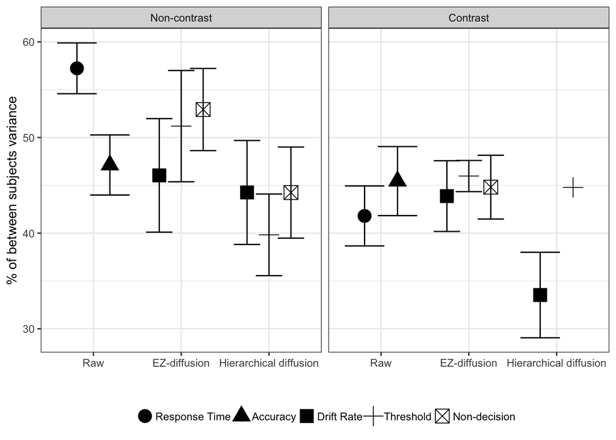

```r
rel_df %>%
  filter(rt_acc != "other") %>%
  group_by(rt_acc, contrast, raw_fit) %>%
  summarise(mean_var_subs_pct = mean(var_subs_pct),
            mean_var_ind_pct = mean(var_ind_pct),
            mean_var_resid_pct = mean(var_resid_pct),
            sem_var_subs_pct = sem(var_subs_pct),
            sem_var_ind_pct = sem(var_ind_pct),
            sem_var_resid_pct = sem(var_resid_pct)) %>%
  ggplot(aes(factor(raw_fit, levels = c("raw", "EZ", "hddm"), labels=c("Raw", "EZ-diffusion", "Hierarchical diffusion")), mean_var_subs_pct, shape=factor(rt_acc, levels = c("rt","accuracy", "drift rate", "threshold", "non-decision"), labels=c("Response Time", "Accuracy","Drift Rate", "Threshold", "Non-decision"))))+
  geom_point(position=position_dodge(width=0.75), size = 5)+
  geom_errorbar(aes(ymin = mean_var_subs_pct - sem_var_subs_pct, ymax = mean_var_subs_pct + sem_var_subs_pct), position=position_dodge(width=0.75))+
  facet_wrap(~factor(contrast, levels=c("non-contrast", "contrast"), labels=c("Non-contrast", "Contrast")))+
  ylab("% of between subjects variance")+
  xlab("")+
  theme(legend.title = element_blank(),
        legend.position = 'bottom')
```

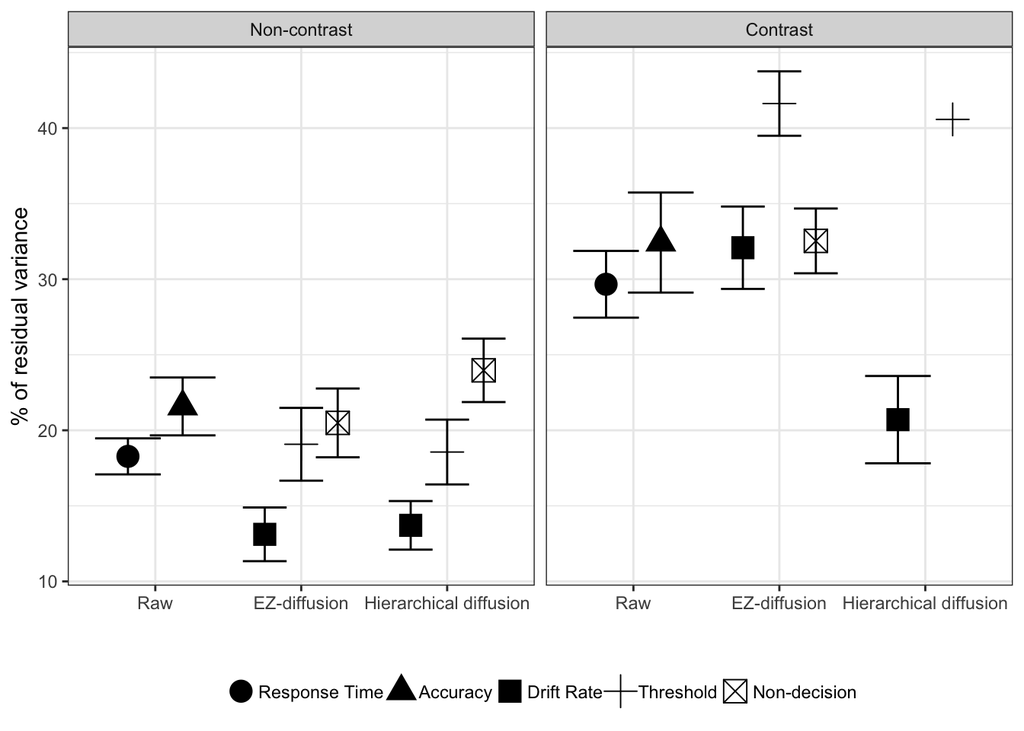

```r
rel_df %>%
  filter(rt_acc != "other") %>%
  group_by(rt_acc, contrast, raw_fit) %>%
  summarise(mean_var_subs_pct = mean(var_subs_pct),
            mean_var_ind_pct = mean(var_ind_pct),
            mean_var_resid_pct = mean(var_resid_pct),
            sem_var_subs_pct = sem(var_subs_pct),
            sem_var_ind_pct = sem(var_ind_pct),
            sem_var_resid_pct = sem(var_resid_pct)) %>%
  ggplot(aes(factor(raw_fit, levels = c("raw", "EZ", "hddm"), labels=c("Raw", "EZ-diffusion", "Hierarchical diffusion")), mean_var_resid_pct, shape=factor(rt_acc, levels = c("rt","accuracy", "drift rate", "threshold", "non-decision"), labels=c("Response Time", "Accuracy","Drift Rate", "Threshold", "Non-decision"))))+
  geom_point(position=position_dodge(width=0.75), size = 5)+
  geom_errorbar(aes(ymin = mean_var_resid_pct - sem_var_resid_pct, ymax = mean_var_resid_pct + sem_var_resid_pct), position=position_dodge(width=0.75))+
  facet_wrap(~factor(contrast, levels=c("non-contrast", "contrast"), labels=c("Non-contrast", "Contrast")))+
  ylab("% of residual variance")+
  xlab("")+
  theme(legend.title = element_blank(),
        legend.position = 'bottom')
```

Model testing if the percentage of between subjects variance of raw measures differs from that of ddm estimates and if contrast measures differ from non-contrast measures.

Checking if both fixed effects of raw vs ddm and contrast vs non-contrast as well as their interaction is necessary.

Conclusion: Model with fixed effects for both is best.

```r
mer1 = lmer(var_subs_pct ~ ddm_raw + (1|dv), boot_df %>% filter(rt_acc != "other"))
mer1a = lmer(var_subs_pct ~ contrast + (1|dv), boot_df %>% filter(rt_acc != "other"))
mer2 = lmer(var_subs_pct ~ ddm_raw + contrast + (1|dv), boot_df %>% filter(rt_acc != "other"))
mer3 = lmer(var_subs_pct ~ ddm_raw * contrast + (1|dv), boot_df %>% filter(rt_acc != "other"))
anova(mer1, mer2, mer3)
```

```
refitting model(s) with ML (instead of REML)
```

|  | Df | AIC | BIC | logLik | deviance | Chisq | Chi Df | Pr(>Chisq) |
| --- | --- | --- | --- | --- | --- | --- | --- | --- |
| mer1 | 4 | 2002392 | 2002434 | -1001192 | 2002384 | NA | NA | NA |
| mer2 | 5 | 2002362 | 2002414 | -1001176 | 2002352 | 32.101 | 1 | 1.463e-08 |
| mer3 | 6 | 2002362 | 2002425 | -1001175 | 2002350 | 1.139 | 1 | 2.859e-01 |

```r
anova(mer1a, mer2, mer3)
```

```
refitting model(s) with ML (instead of REML)
```

|  | Df | AIC | BIC | logLik | deviance | Chisq | Chi Df | Pr(>Chisq) |
| --- | --- | --- | --- | --- | --- | --- | --- | --- |
| mer1a | 4 | 2002368 | 2002410 | -1001180 | 2002360 | NA | NA | NA |
| mer2 | 5 | 2002362 | 2002414 | -1001176 | 2002352 | 8.052 | 1 | 0.004545 |
| mer3 | 6 | 2002362 | 2002425 | -1001175 | 2002350 | 1.139 | 1 | 0.285934 |

```r
rm(mer1, mer1a, mer3)
```

Raw and non-contrast measures have higher between subjects variance (ie are between individual difference measures)

```r
summary(mer2)
```

```
Linear mixed model fit by REML ['lmerMod']
Formula: var_subs_pct ~ ddm_raw + contrast + (1 | dv)
   Data: boot_df %>% filter(rt_acc != "other")

REML criterion at convergence: 2002344

Scaled residuals:
   Min     1Q Median     3Q    Max
-4.126 -0.659  0.076  0.674  4.702

Random effects:
 Groups   Name        Variance Std.Dev.
 dv       (Intercept) 171      13.1
 Residual             105      10.2
Number of obs: 267000, groups:  dv, 267

Fixed effects:
                     Estimate Std. Error t value
(Intercept)             41.64       1.39   30.05
ddm_rawraw               4.65       1.64    2.84
contrastnon-contrast     9.54       1.64    5.81

Correlation of Fixed Effects:
            (Intr) ddm_rw
ddm_rawraw  -0.415
cntrstnn-cn -0.654 -0.107
```

Model testing if the percentage of residual variance of raw measures differs from that of ddm estimates and if contrast measures differ from non-contrast measures.

Checking if both fixed effects of raw vs ddm and contrast vs non-contrast as well as their interaction is necessary.

Conclusion: Model with fixed effect just for contrast is best. And plot above already shows that contrast measures have higher residual variance.

```r
mer1 = lmer(var_resid_pct ~ ddm_raw + (1|dv), boot_df %>% filter(rt_acc != "other"))
mer1a = lmer(var_resid_pct ~ contrast + (1|dv), boot_df %>% filter(rt_acc != "other"))
mer2 = lmer(var_resid_pct ~ ddm_raw + contrast + (1|dv), boot_df %>% filter(rt_acc != "other"))
mer3 = lmer(var_resid_pct ~ ddm_raw * contrast + (1|dv), boot_df %>% filter(rt_acc != "other"))
anova(mer1, mer2, mer3)
```

```
refitting model(s) with ML (instead of REML)
```

|  | Df | AIC | BIC | logLik | deviance | Chisq | Chi Df | Pr(>Chisq) |
| --- | --- | --- | --- | --- | --- | --- | --- | --- |
| mer1 | 4 | 1719708 | 1719750 | -859850 | 1719700 | NA | NA | NA |
| mer2 | 5 | 1719600 | 1719653 | -859795 | 1719590 | 109.4118 | 1 | 1.318e-25 |
| mer3 | 6 | 1719602 | 1719665 | -859795 | 1719590 | 0.5357 | 1 | 4.642e-01 |

```r
anova(mer1a, mer2, mer3)
```

```
refitting model(s) with ML (instead of REML)
```

|  | Df | AIC | BIC | logLik | deviance | Chisq | Chi Df | Pr(>Chisq) |
| --- | --- | --- | --- | --- | --- | --- | --- | --- |
| mer1a | 4 | 1719599 | 1719641 | -859795 | 1719591 | NA | NA | NA |
| mer2 | 5 | 1719600 | 1719653 | -859795 | 1719590 | 0.3849 | 1 | 0.5350 |
| mer3 | 6 | 1719602 | 1719665 | -859795 | 1719590 | 0.5357 | 1 | 0.4642 |

```r
rm(mer1, mer1a, mer2, mer3)
```

## Sample size effects

- Change in parameter values depending on full vs. retest only sample – How much do parameter values change depending on whether the model was fit using the whole sample vs only the retest sample.

NOTE: The lack of clear systematicity in the changes of the parameter estimates can be difficult to interpret. A systematic change would have meant that the ranking remained the same regardless of the sample size. When the change is non-systematic in this way then a given subject that has high higher drift rates than most of the people in the full sample can appear to have lower drift rates than the same people when fit on the retest sample only.

Of course these parameter estimates themselves are not very interpretable in their ‘goodness’ as they don’t reflect anything about model fits. To determine the model fits for both cases I have written functions to sample from the posterior predictive and calculate $R^2$’s for each subject.

### Parameter reliability

- Parameter reliability depending on sample size: in addition to comparing just 150 vs 500

The reliability of a measure depends on the different sources of variability. It would be larger the larger the between subject variability (BSV) is (and the lower within subject, WSV, and error variances, ERV, are). Larger sample sizes do not necessarily imply larger BSV. If there is a true BSV for the whole sample then BSV’s of subsamples would have distribution that would be centered around this value with some variance. This variance would be smaller the larger the sample size. Because the distribution is centered around the true BSV the median reliability estimate from 100 samples would not deviate. But the variance of that reliability estimate would. Specifically the variance of the reliability estimates should decrease with increasing sample size.

## Hierarchical estimation consequences

- Is the H in HDDM important? (h vs flat) – Change in parameter value? – Change in parameter reliability?

## Clustering

– Do DDM parameters capture similar processes as the raw measures in a given task or do they capture processes that are more similar across tasks? – Are these clusters more reliable than using either the raw or the DDM measures alone?

## Prediction

– Do raw or DDM measures (or factor scores) predict real world outcomes better?

## To Do

Prof. Domingue recommended readings: file:///Users/zeynepenkavi/Downloads/10.1007%252Fs11336-006-1478-z.pdf A HIERARCHICAL FRAMEWORK FOR MODELING SPEED AND ACCURACY ON TEST ITEMS

file:///Users/zeynepenkavi/Downloads/v66i04.pdf Fitting Diffusion Item Response Theory Models for Responses and Response Times Using the R Package diffIRT